# Elementary Statistics (STAT 201)

# Association between different variables

## Association

- An association exists between two variables if particular values of one variable and particular values of the other variable are likely to occur together.

[figure not shown]

- **Response variable** (Dependent Variable)
  - the outcome variable on which comparisons are made
- **Explanatory variable** (Independent variable)
  - defines the groups to be compared with respect to values on the response variable

## Contigency table - visualize two categorical variables

- Its rows list the categories of one variable.
- Its columns list the categories of the other variable.
- Its entries (cells) are the frequency, i.e. the number of observations that fall in both categories.

[interactive chart not shown]

## Regression -- association between two quantitative variables

### Scatter plot - visualize two quantitative variables

- If we have two quantitative variables, we can graphically display the two variables using a scatter plot on the x-y plane, where
  - the explanatory variable is on the horizontal axis (x-axis)
  - the response is on the vertical axis (y-axis)

### Example: Old Faithful Geyser in Yellowstone National Park.

- Variables:
  - Waiting time between eruptions (Response)
  - Duration of the eruption (Explanatory)

[figure not shown]

### Scatter plot

[figure not shown]

### Scatter plot

- We use the scatter plot to examine three aspects of the association between the two variables:
  - Trend (pattern): linear, curved, no pattern, etc.
- Direction: positive, negative, no direction
  - Positive: as X increases, Y increases
  - Negative: as X increases, Y decreases
  - No direction: the increases in X does not affect Y (no association)
- Strength: how closely the points fit the trend

### Scatter plot

- In general, we care about whether there is **linear trend** between the two variables.
- How to measure **linear trend** ?

### Correlation coefficient

- We can measure the strength of linear association between two variables using the **correlation coefficient**, denoted by $r$.

### Basic properties of correlation coefficient $r$

- −1 ≤ r ≤ 1
- If r > 0, there is a positive association between X and Y - Y increases as X increases
- If r < 0, there is a negative association between X and Y - Y decreases as X increases
- The closer r is toward 1 or −1, the stronger the evidence of linear association is.
- The closer r is toward 0, the weaker the evidence of linear association is.

### Correlation coefficient 𝑟

[figure not shown]

- Noticed in the last row, there exist some curved association between X and Y, but the correlation coefficient is 0.
- This is because, correlation coefficient can only measure **linear association**.

### Predicting the Outcome of the Response - regression line

- A **regression line** predicts the value for the response variable Y as a straight-line function of the value X of the explanatory variable.

### Regression line

- Let $\hat{y}$ (y-hat) denote the predicted value (fitted value) of the response y, and x the explanatory variable. The equation of the regression line is given by

  $$\hat{y} = a + bx $$
- where
  - a is the **y-intercept**: the predicted value of y when x = 0. When it is not meaningful to assign x = 0 to the explanatory variable, a does not have a specific meaning.
  - b is the **slope**: the average increase in the response y as the explanatory variable x increases by 1 unit.
    - If b > 0, there is a positive linear association between X and Y .
    - If b < 0, there is a negative linear association between X and Y .

## Residual

- Residual is defined as: $$ Residual = y - \hat{y}$$
- Residual can be viewed as the error in prediction.

### How do we get the regression line?

- A common procedure to find the regression line is called the **least-squares** method.
- Using the least-squares method, the regression line always provides the smallest amount of total prediction error, which is called the residual sum of squares.

### How do we measure the performance of regression line?

- $R^2$ (**R-squared**) measures how well the regression line fits the data.
- $R^2$ is defined as $$R^2 = \frac{Variability\ in\ Y\ explained\ by\ regression}{Total\ variability\ in\ Y}$$

which is the proportion (percentage) of the variability in Y explained by the the regression.

### $R^2$ and $r$

- Connection between R-squared $R^2$ and correlation coefficient $r $:
  - If $b>0$, $ r = \sqrt{R^2}$
  - If $b<0$, $ r = -\sqrt{R^2}$
- Recall $b$ is the slope in the regression line

## Cautions in Regression

- **Extrapolation** – using linear regression to make predictions for values of x that are outside of the range of collected data is risky.
- **Influential outliers**

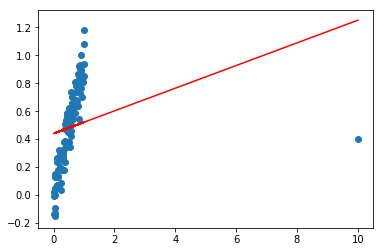

```python
import matplotlib.pyplot as plt
%matplotlib inline
import numpy as np

X = np.random.rand(100)
Y = X + np.random.normal(0,1,100)/10

X = np.append(X, 10).reshape(101,1)
Y = np.append(Y, 0.4).reshape(101,1)

from sklearn.linear_model import LinearRegression
regr = LinearRegression().fit(X,Y)
y_pred = regr.predict(X)


plt.scatter(X,Y)
plt.plot(X,y_pred, "r")
```

- **Correlation does not imply causation**
  - Famous example: People observed, as the sales of ice cream go up, the incidents of drowning go up as well.
  - Does this means **ice cream causes drowning** ?

[interactive chart not shown]